# High frequency oscillations (HFOs)

$~$ $~$

##### The initial studies on HFOs in the hippocampus found that ripples were found as a physiologic variant and fast ripples were a marker of epileptogenesis.

##### True.

##### False.

$~$ True. The first studies on HFOs were focused mostly on the hippocampus. There, ripples (frequencies between approximately 80 and 250 Hz) were found in non-epileptogenic hippocampus while fast ripples (frequencies above 250 Hz) were found in epileptogenic hippocampus. A high ratio of fast ripples to ripples correlated with epileptic disease severity. This was found in both rodents and humans giving an impression of a definitive finding. Things were simple and clear. Everybody was happy. It turned out to be much more complicated than that.

$~$ $~$

##### When HFOs were evaluted in different brain regions it was further confirmed that ripples are markers of physiological activity and fast ripples are markers of pathologic tissue.

##### True.

##### False.

$~$ False. When studies evaluated HFOs in different parts of the brain, it became clear that, depending on the brain region, both ripples or fast ripples can reflect epileptic activity or physiological processes.

$~$ $~$

##### But within each brain region, HFOs (ripples or fast ripples) are clear markers of physiologic or epileptogenic tissue, right?

| Study | Results |
| --- | --- |
| Jacobs et al, 2009 | R and FR, p<0.001 |
| Bagshaw et al, 2009 | R and FR, p<0.001 |
| Kerber et al, 2013 | R and FR, p<0.001 |

##### Considering the table above, which is a random sample from Table 1 (relationship between HFOs and seizure onset zone), how would good you would say are HFOs to localize the SOZ?

##### Extremely good.

##### Very good.

##### Just fair.

##### Bad.

##### Very bad.

##### I do not know.

$~$ The correct answer is “I do not know”. Table 1 (also Table 2) only gives you p-values. p-values are measures of statistical significance, not effect measures. p-values depend on both the magnitude of the correlation and the sample size. Huge sample sizes will give you very small p-values even for very small effect sizes. Just as an example, Bagshaw et al, 2009 uses 11,734 ripples and 4,771 fast ripples.

Table 1 (also Table 2) does not give you any measure to evaluate the effect size. Additionally, they do not even give you information on what is the outcome.

$~$ $~$

##### So I extracted that information from the articles. Now, how good you would say are HFOs to localize the SOZ?

| Study | Outcome | Results | Clinical_Results |
| --- | --- | --- | --- |
| Jacobs et al, 2009 | Duration of ripples | R and FR, p<0.001 | Non-lesional SOZ: 89.1 +- 39.8 ms; Lesional SOZ: 81.1 +- 31.8 ms; p<0.001 |
| Bagshaw et al, 2009 | Ripples in and out SOZ | R and FR, p<0.001 | Ripples SOZ: 12/min; non-SOZ: 3/min; p < 0.000001 |
| Kerber et al, 2013 | Ripples in and out SOZ | R and FR, p<0.001 | Ripples SOZ: 38.8 (95% CI: 34.7-42.9); non-SOZ: 22.7 (95% CI: 20.7-24.7); p < 0.001 |

##### Extremely good.

##### Good.

##### Just fair.

##### Bad.

##### Very bad.

##### I do not know.

$~$ The effect size (the number of ripples and fast ripples between the SOZ and the non-SOZ) is not very large really (good?, just fair?).

This is how Kerber et al distributions would look like:

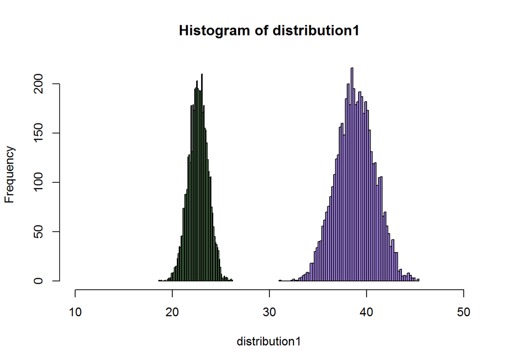

It is statistically significant, though. Do you understand why it is statistically significant?

$~$ $~$

##### But, but, but, HFOs are very consistent measures of brain activity, right? Select the sentence that best defines HFOs:

##### Ripples and fast ripples have a single definition used consistently across different studies; the electrodes with which they are measured are always the same type; and their identification is also standardized across different studies.

##### Ripples and fast ripples have a somewhat varying definition across different studies; the electrodes with which they are measured are mostly of the same type; and their identification is more or less standardized across different studies.

##### The definition of ripples and fast ripples is highly variable in different studies; the electrodes with which they are measured are highly variable; the identification varies very widely between studies.

$~$ Ripples and fast ripples are defined with a huge variability of Hz ranges across different studies as you can see in Tables 1 and 2. They can be measured with macro or micro electrodes of different types, compositions, and locations in the brain; the identification of ripples and fast ripples relies on a highly subjective human identification or in non-validated automatic methods (or a combination of both) which is different accross studies.

$~$ $~$

##### So HFOs are highly variable? Select all the factor(s) that modify the rate of HFOs:

##### Brain region.

##### Wake/sleep stage.

##### Type of electrodes.

##### Medications.

##### EEG filters.

##### Sampling rate.

##### EEG background.

##### Intra-patient variability.

##### Inter-patient variability.

$~$ All the factors above (including many medications used during the EEG monitoring and many ASMs) can increase or decrease the rate of HFOs. Some authors argue that HFOs even have a different meaning depending on how the background looks like around the HFOs. There is also a huge intra-patient and inter-patient variability in the rate of HFOs.

$~$ $~$

##### So there is no threshold of HFOs that is normal/abnormal:

##### True.

##### False.

$~$ True. There is no threshold that defines normal or abnormal rate of HFOs for a population, a patient, or even a brain region within a patient.

$~$ $~$

##### Does that mean that every ripple or fast ripple may be either physiological or pathological?

##### True.

##### False.

$~$ True. The chapter states exactly that: that every ripple or fast ripple may be either physiological or pathological. Is not that funny?

$~$ $~$

##### Wait, but the field of HFOs is flourishing and represents one of the most active fields of research in epilepsy, right? There must be some promising results, right?

##### True.

##### False.

$~$ True. When considered as a group of several patients, HFOs are (moderately, as we saw above) more frequent in the SOZ than in the non-SOZ and there are significant (do you remember about statistical significance from above?) correlations between the amount of HFO zones removed and the outcome.

$~$ $~$

##### Wow! That sounds great. On an unrelated topic, men score better on math than women do. Jerry is a man. Therefore, Jerry is better at math than Sylvia, who is a woman. Is this true or false?

##### True.

##### False.

$~$ False. The fact that men score better on math than women is a group generalization. This does not mean that any individual man will score better than any individual woman on math. This is because there could be what is referred to as an uneven distribution, that is, there could be a small group of women who are really bad at math or a small group of men who are really good at math that throws off the curve. This whole concept is called “ecological fallacy”. In the chapter they refer to it as “group analysis”.

$~$ $~$

##### But that does not mean that the group relationship is not real, right? It can be that there is a relationship between HFOs (or ripples or fast ripples) and SOZ at an individual level, right?

##### True.

##### False.

$~$ True. It can be that HFOs are related to the SOZ at the individual level. It is possible. That is the hope. It was the hope in the 2000s. It continues to be the hope in the 2020s. It can be that it is all an ecological fallacy with weak a-posteriori associations at a group level. The following concept from the chapter gives insight at where we are in 2020: Associations at a group level in retrospective studies, but no evidence for HFOs to taylor a resection.

$~$ $~$

##### Wait. HFOs associated with spikes are better. It is the HFOs associated with spikes! Not the HFOs alone. That is it. Select the correct statement below:

##### HFOs associated with spikes are more specific markers of the SOZ than HFOs alone.

##### HFOs associated with spikes are not better markers of the SOZ than HFOs alone.

$~$ HFOs associated with spikes are more specific markers of the SOZ than HFOs alone. Yeaahh. Kind of. They are somewhat more specific. But there are two major limitations on that:

1. Spikes are associated with the SOZ by themselves, so HFOs associated with spikes are necessarily more associated with the SOZ than HFOs not associated with spikes. Like HFOs detected in France are probably associated with patients who speak French, not because of HFOs associated with France being a marker of speaking French, but because patients in France are probably good French speakers (with or without HFOs).
2. Still HFOs with spikes do not appear to be a great biomarker of the SOZ (statistically significant, but not great effect sizes) and the association still depends on many confounders and is highly variable.

$~$ $~$

##### So we have HFOs, a biomarker of epileptogenesis that (select all correct answer(s)):

##### Varies widely in its definition.

##### Does not have an objective threshold of normal/abnormal.

##### Identification of HFOs is non-standarized and varies from center to center.

##### Is influenced by multiple potential confounders.

##### Studies on HFOs study multiple potential outcomes (correlation of HFOs with SOZ, correlation of HFOs with irritative zone, correlation of HFOs with surgical outcome).

##### HFOs studies have found correlations a-posteriori and at a group level, not a-priori and at an individual level.

$~$ All sentences are true. The whole field of HFOs is quite nebulous with multiple definitions, multiple outcomes, variable and subjective ways to measuring HFOs, and statistically significant associations with weak effect measures.

Hopefully, this field of research becomes more clinically applicable over the years.

However, the best summary of the importance of HFOs to the clinical management of patients as of now is presented in the chapter with the following concept: resections have never been taylored according to HFOs.